# presentation_comap

Under the Spotlight

Why Media Exposure Shapes Authoritarian Legislators’ Rhetoric

**Artur Baranov**  
Northwestern University  
artur.baranov@u.northwestern.edu

[artur-baranov.github.io](https://artur-baranov.github.io/)

## Media in (democratic) Politics

When the press covers a bill, voters learn about it, and parties and members adjust what they say and do

- Media attention to an issue moves parliamentary activities [(Vliegenthart et al., 2016)](https://doi.org/10.1111/1475-6765.12134)
- If media cover representatives more, the representatives work harder for their districts [(Snyder and Strömberg, 2010)](https://doi.org/10.1086/652903)

Responsiveness is driven by **Electoral Incentives**

## The Spotlight Effect

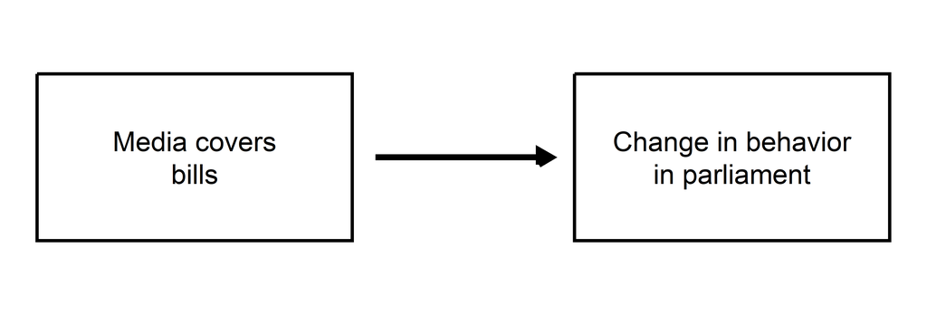

## The Spotlight Effect

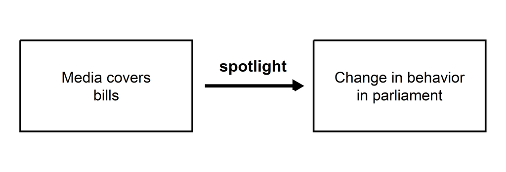

## Parliaments in (autocratic) Politics

Over 90% of authoritarian regimes have a parliament

- Gather information for the regime [(Malesky and Schuler, 2010)](https://doi.org/10.1017/S0003055410000250)
- Harmonize the elites interest [(Meng, Paine and Powell, 2023)](https://doi.org/10.1146/annurev-polisci-052121-020406)

Responsiveness is driven by **Regime**

## Authoritarian Spotlight Effect

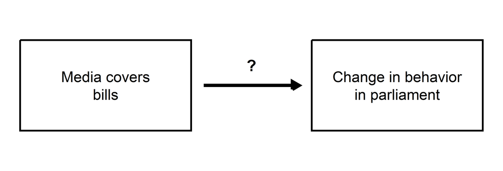

## Spoiler Alert

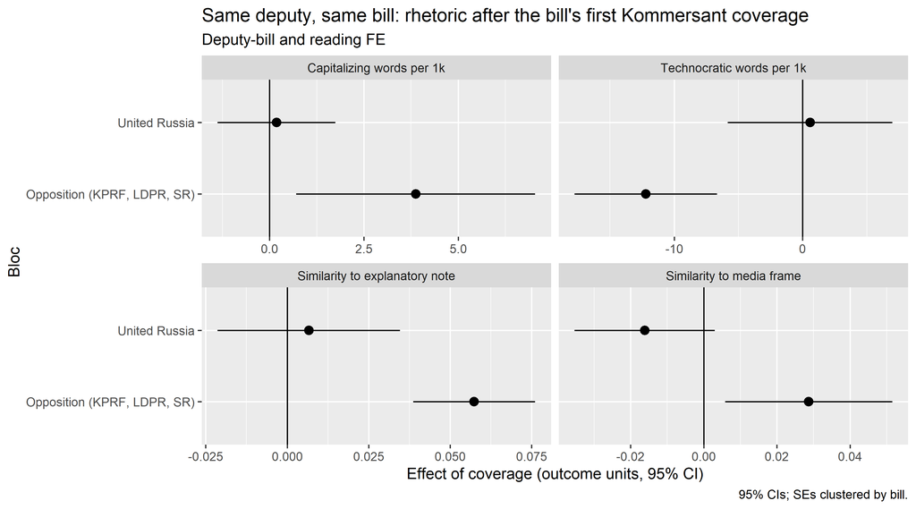

## Argument

Media attention creates an **audience** for a bill

- **Capitalize**: speak to that audience, about citizens, blame and credit
  - Pays off only where it does not mean confronting the executive
  - Systemic opposition, on bills the government and the president did not introduce

## Argument

Media attention creates an **audience** for a bill

- **Defuse**: keep the bill technical, stay on the official script, away from the media frame
  - Ruling party, which owns the agenda and gains nothing from attention

## Case

Russia, 7th Convocation of State Duma (2016-2021).

- Competitive Authoritarian Regime
- Ruling party with supermajority (United Russia)
- Nominal Opposition parties (Communists, Nationalists, etc.)

## Data

26,182 speeches, 4,523 bills and 4299 news articles

- Parliamentary floor speeches, debates and discussion on the bills
- Bill Information, explanatory notes
- Kommersant, a business daily with a high-profile and comparatively neutral political outlet

## Which Article Covers What Bill?

## Matching articles to bills

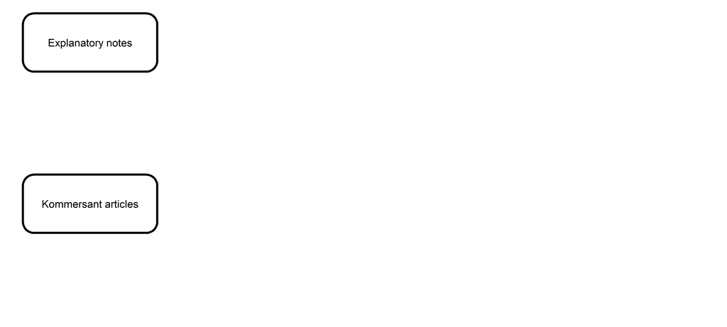

## Matching articles to bills

**Explanatory note**, bill 733024-7

> The draft federal law “On Amendments to the Tax Code of the Russian Federation” (hereinafter, the bill) was prepared pursuant to Government Instruction No. SA-P13-67pr of 18 October 2018 and item 50 of section XI of the Government’s legislative plan… The bill proposes to exempt from value added tax (hereinafter, VAT) the import… of civil aircraft subject to state registration…

**Kommersant**, 13 June 2019

> **Value-Added Flight Hours**  
> Russian airlines keep zero VAT on foreign aircraft  
> “With a 1.5% margin at the most successful Russian airlines, a 20% VAT would kill the whole economics of buying new aircraft,” an industry source told Kommersant. …

## Matching articles to bills

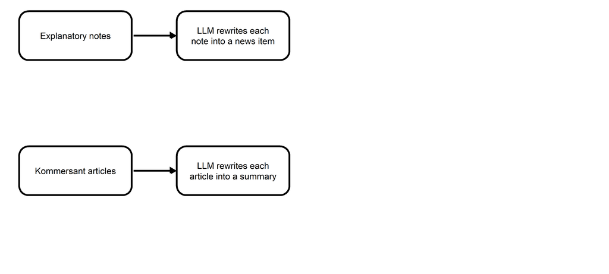

## Matching articles to bills

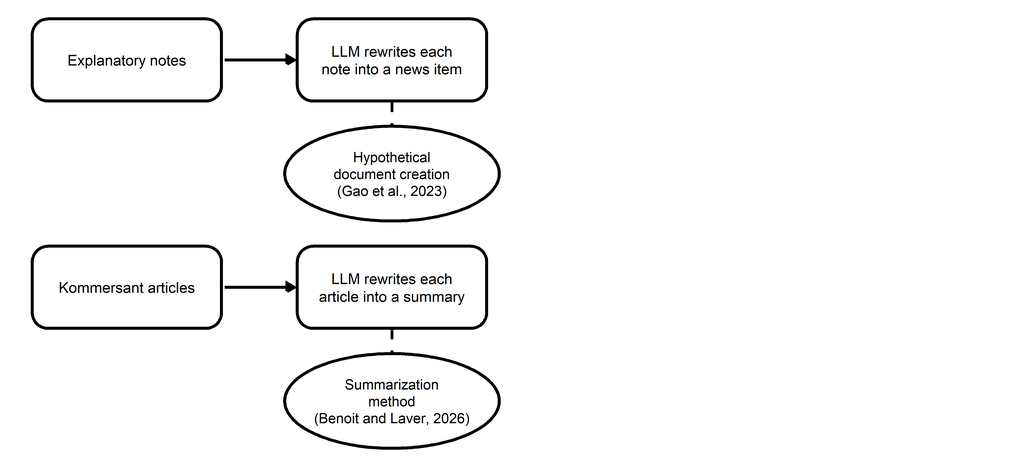

## Matching articles to bills

**Explanatory note → news item**

The bill changes tax conditions for airlines, shipowners and participants in the special administrative regions in Kaliningrad Oblast and Primorsky Krai. **Imports of civil aircraft registered in the Russian state register**, as well as **aircraft engines and components** for their construction, repair and modernization, are to be **exempted from VAT**; a 0% rate is to apply to sales of such aircraft, construction work, leasing and sales of components. **Until 1 January 2023**, the VAT exemption remains for imports of **aircraft registered in foreign registers**, on presentation of the registration certificate to customs. The **Tax Code** amendments also provide benefits for vessels in the Russian Open Register and a zero rate of social insurance contributions for crews through 2027.

**Kommersant article → news item**

The bill would **zero-rate VAT** on **imports of foreign aircraft if they are registered in the Russian state register** of civil aircraft. The rate would apply indefinitely. **Aircraft entered in the registers of countries** with which Russia has international agreements get a temporary tax exemption **until 1 January 2023**; this covers, in particular, aircraft registered in Bermuda. The **Tax Code** amendments would also **exempt from VAT** imports of **aircraft engines, spare parts and components** for building Russian aircraft, prototypes for testing, and domestic aircraft themselves, including the SSJ 100 and MC-21.

## Matching articles to bills

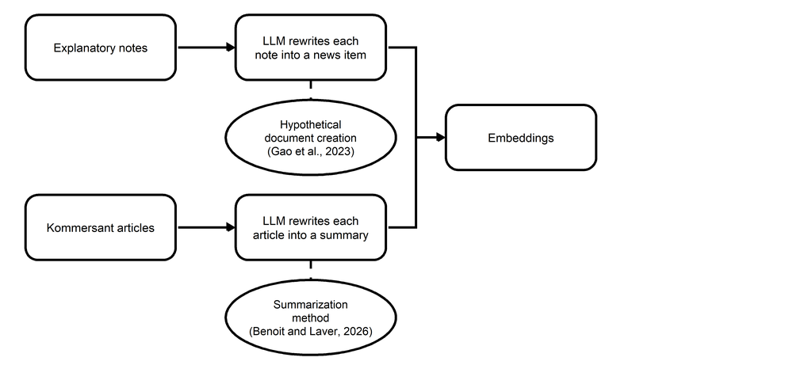

## Matching articles to bills

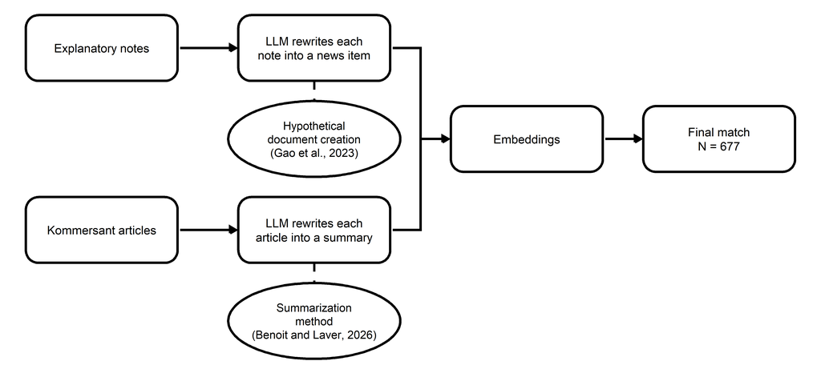

## Matching articles to bills

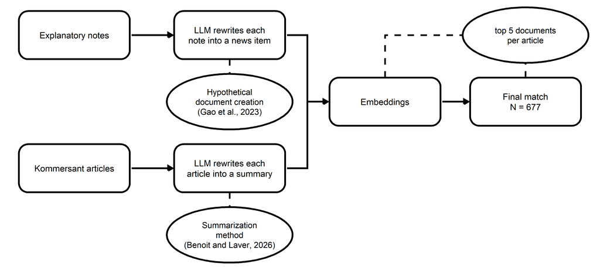

## Measurement

**Vocabulary**: dictionaries of Russian word stems, per 1,000 words

- Capitalizing: citizens, public reaction, moral evaluation, partisan credit
- Technocratic: legal, fiscal, procedural, expert

**Similarity** (tf-idf cosine) of each speech to

- the bill’s explanatory note
- Kommersant’s coverage of the bill

## Design

**Problem**: media attention is not random. Covered bills differ from the rest

**Solution**: difference in difference

- I compare the same deputy speaking on the same bill before and after the bill’s first coverage
- Against the same change across readings for deputies whose bill is not (yet) covered
- Fixed effects for deputy × bill and for reading; SEs clustered by bill

## Design

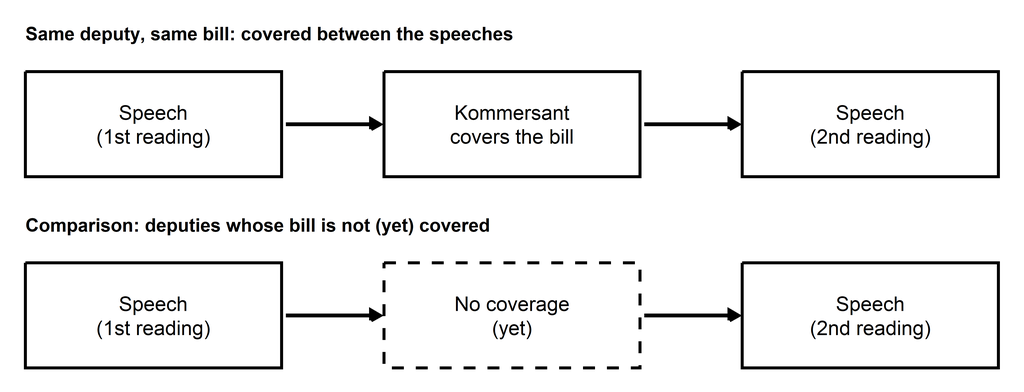

## Results

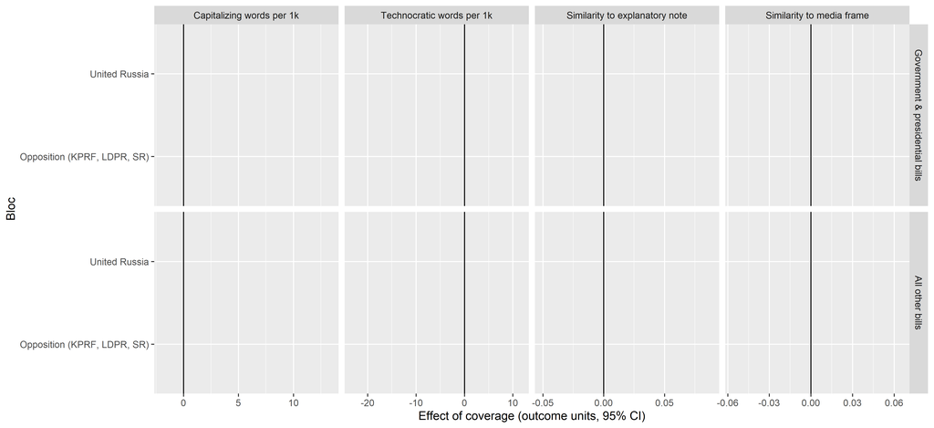

## Results

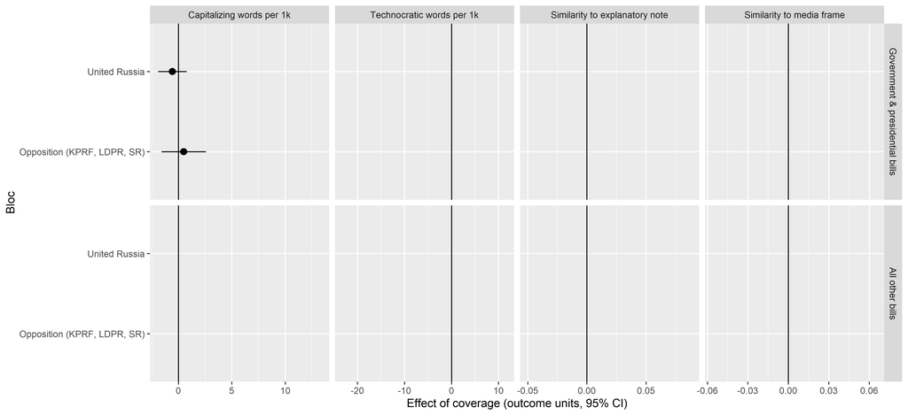

## Results

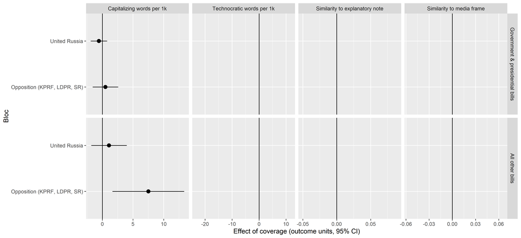

## Results

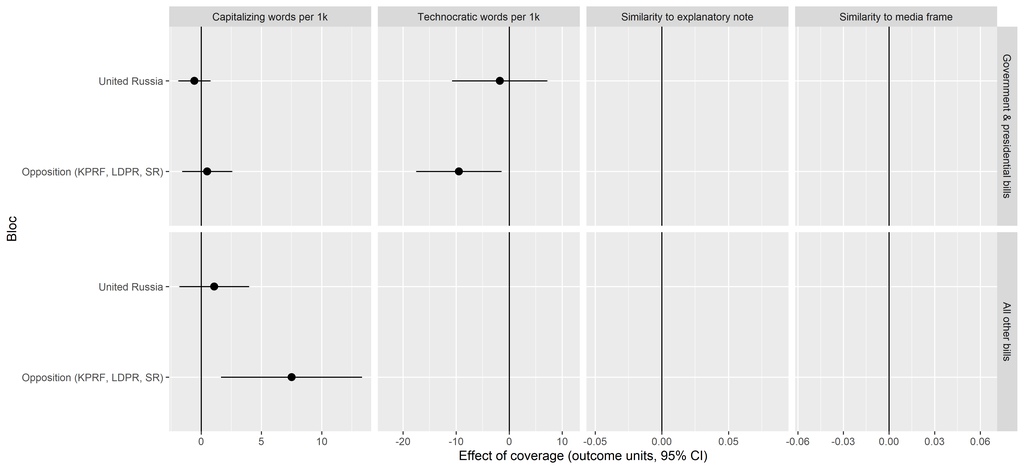

## Results

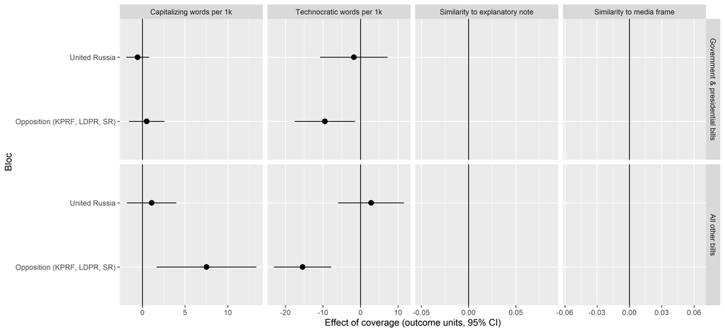

## Results

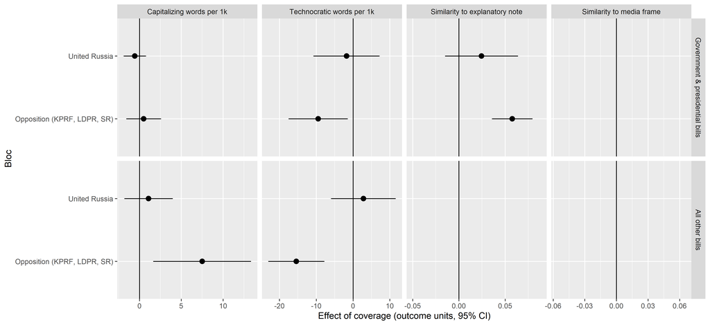

## Results

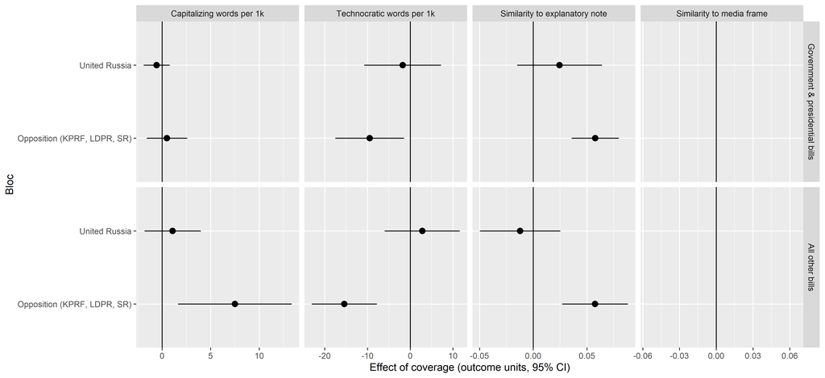

## Results

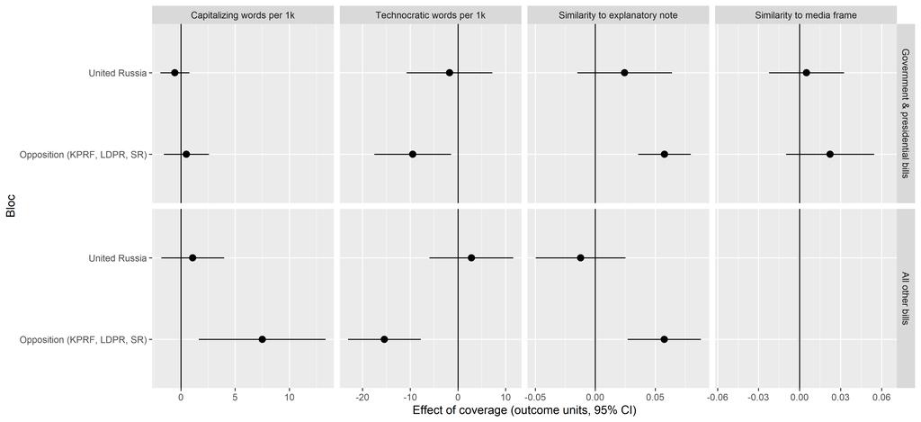

## Results

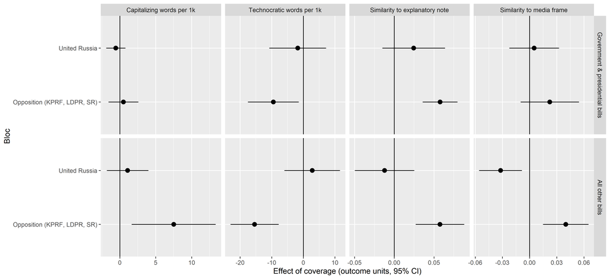

## Reverse Causality?

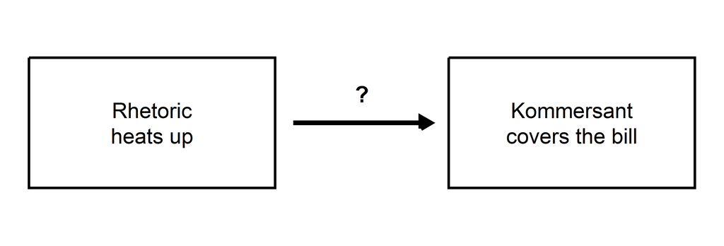

## Placebo

Deputies who finished speaking **before** the bill was covered

- Were their speeches already changing between the first and later speech?

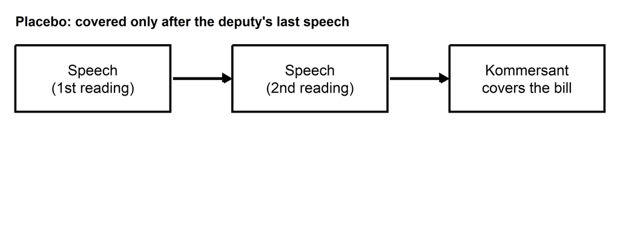

## Placebo

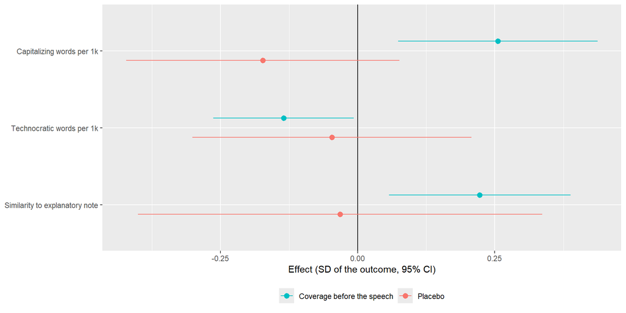

## Takeaways

Even in an autocracy, parties **respond to the media spotlight**

- **Opposition** capitalizes, but only on bills the executive did not introduce
- **Ruling party** tries to defuse it, moving its rhetoric away from the media frame

Responsiveness is driven by a party’s **position toward the regime**

Artur Baranov  
artur.baranov@u.northwestern.edu

[artur-baranov.github.io](https://artur-baranov.github.io/)

## Takeaways

Even in an autocracy, parties **respond to the media spotlight**

- **Opposition** capitalizes, but only on bills the executive did not introduce
- **Ruling party** tries to defuse it, moving its rhetoric away from the media frame

Responsiveness is driven by **Electoral Incentives Mechanisms**?

Artur Baranov  
artur.baranov@u.northwestern.edu

[artur-baranov.github.io](https://artur-baranov.github.io/)

## Takeaways

Even in an autocracy, parties **respond to the media spotlight**

- **Opposition** capitalizes, but only on bills the executive did not introduce
- **Ruling party** tries to defuse it, moving its rhetoric away from the media frame

Responsiveness is driven by a party’s **position toward the regime**

Artur Baranov  
artur.baranov@u.northwestern.edu

[artur-baranov.github.io](https://artur-baranov.github.io/)

## Appendix: Robustness

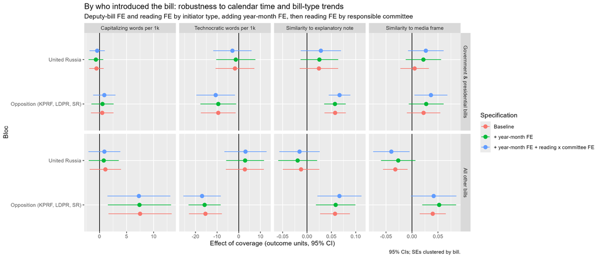

## Appendix: Prompt, Explanatory Note

```
You are a legal correspondent at a Russian newspaper. You have the access to the explanatory note
to a draft federal law submitted to the State Duma.

Write the short news item you would publish about this bill: in Russian,
80–120 words, one paragraph. Start with what the bill would change and for
whom, then give the concrete details a reader would remember: figures,
thresholds, deadlines, named agencies, programmes or regions, and the law or
code being amended, by its usual short name (КоАП, Налоговый кодекс).
Write numbers in digits.

Use only the note. Do not add authors, dates, reactions, quotes or context
the note does not give, and leave out its justification and standard
formulas. Output only the text of the item
```

## Appendix: Prompt, Article

```
You are a legal correspondent at a Russian newspaper. You have the access to a news article.

Find every federal draft law the article reports on: under consideration
in the State Duma, being prepared for submission, or just passed or signed.
Laws adopted earlier, regional and foreign bills, decrees and court rulings
do not count.

For each bill, write the short news item you would publish about it: in
Russian, 80–120 words, one paragraph. Start with what the bill would
change and for whom, then give the concrete details a reader would
remember: figures, thresholds, deadlines, named agencies, programmes or
regions, and the law or code being amended, by its usual short name
(КоАП, Налоговый кодекс). Write numbers in digits.

Use only the article. Leave out authors, reactions, quotes and what
happened to the bill in the Duma, and describe it as a proposal, whatever
its stage.

Example:
Законопроект установит предельный возраст для руководителей и заместителей
руководителей государственных и муниципальных медицинских организаций:
занимать эти должности можно будет до 65 лет. Учредитель сможет продлить
пребывание руководителя в должности до 70 лет. Поправки в Трудовой кодекс
вступят в силу 1 июня 2017 года.

Return one item per bill, or NA if there are none
```

## Appendix: Capitalizing Vocabulary

| Category | Examples |
| --- | --- |
| Citizens | граждане (citizens), избиратели (voters), население (population), народ (the people), пенсионеры (pensioners), многодетные (large families), бюджетники (public-sector workers) |
| Constituency | в моём округе (in my district), мои избиратели (my voters), на местах (in the regions) |
| Public reaction | общество (society), СМИ (media), журналисты (journalists), резонанс (public outcry), возмущение (indignation), протест (protest), петиции (petitions), жалобы (complaints) |
| Moral evaluation | несправедливость (injustice), позор (disgrace), издевательство (mockery), грабёж (robbery), обман (deception), беспредел (lawlessness), антинародный (anti-people) |
| Partisan credit or blame | наша фракция (our faction), мы добились (we achieved), по нашей инициативе (on our initiative), мы предупреждали (we warned), требуем (we demand) |

## Appendix: Technocratic Vocabulary

| Category | Examples |
| --- | --- |
| Legal-textual | статья (article), пункт (clause), абзац (paragraph), редакция (wording), кодекс (code), федеральный закон (federal law), норма (provision), правоприменение (enforcement), регулирование (regulation) |
| Fiscal and numeric | млрд (bn), млн (mn), процент (percent), рубль (ruble), бюджет (budget), расходы (spending), финансирование (funding), финансово-экономическое обоснование (financial justification) |
| Procedural | комитет (committee), чтение (reading), поправка (amendment), рабочая группа (working group), заключение (official opinion), отзыв (official feedback), за основу (as a basis, i.e. in first reading) |
| Expertise | эксперт (expert), экспертиза (expert review), специалист (specialist), мониторинг (monitoring), анализ (analysis), статистика (statistics), исследование (study), данные (data), оценка (assessment) |

## Appendix: Table, Spoiler Alert

|  | Capitalizing words per 1k | Technocratic words per 1k | Similarity to explanatory note | Similarity to media frame |
| --- | --- | --- | --- | --- |
| Coverage x United Russia | 0.185 | 0.579 | 0.007 | −0.016+ |
|  | (0.797) | (3.264) | (0.014) | (0.010) |
| Coverage x Opposition | 3.874* | −12.205*** | 0.057*** | 0.029* |
|  | (1.614) | (2.829) | (0.010) | (0.012) |
| Num.Obs. | 5298 | 5298 | 5058 | 1407 |

+ p < 0.1, * p < 0.05, ** p < 0.01, *** p < 0.001  
95% CIs; SEs clustered by bill.

## Appendix: Table, Results

|  | Capitalizing words per 1k | Technocratic words per 1k | Similarity to explanatory note | Similarity to media frame |
| --- | --- | --- | --- | --- |
| Coverage x UR, gov./pres. bill | −0.571 | −1.756 | 0.025 | 0.005 |
|  | (0.682) | (4.582) | (0.020) | (0.014) |
| Coverage x UR, other bill | 1.081 | 2.824 | −0.012 | −0.032** |
|  | (1.479) | (4.476) | (0.019) | (0.012) |
| Coverage x Opposition, gov./pres. bill | 0.496 | −9.472* | 0.058*** | 0.022 |
|  | (1.064) | (4.104) | (0.011) | (0.016) |
| Coverage x Opposition, other bill | 7.502* | −15.399*** | 0.058*** | 0.040** |
|  | (2.985) | (3.887) | (0.016) | (0.013) |
| Num.Obs. | 5298 | 5298 | 5058 | 1407 |

+ p < 0.1, * p < 0.05, ** p < 0.01, *** p < 0.001  
95% CIs; SEs clustered by bill.

## Appendix: Table, Designs and Placebo

|  | Same deputy-bill | Same deputy-bill, non-debate coverage | Within bill, across speakers | Placebo: coverage after last speech |
| --- | --- | --- | --- | --- |
| Capitalizing words per 1k | Capitalizing words per 1k | Capitalizing words per 1k | Capitalizing words per 1k | Capitalizing words per 1k |
| Coverage | 1.605+ | 2.538** | 1.093 | -1.719 |
|  | (0.826) | (0.920) | (0.730) | (1.261) |
| Num.Obs. | 5310 | 5310 | 19570 | 3803 |
| Technocratic words per 1k | Technocratic words per 1k | Technocratic words per 1k | Technocratic words per 1k | Technocratic words per 1k |
| Coverage | -4.528+ | -2.690 | -4.182* | -1.456 |
|  | (2.526) | (4.533) | (2.026) | (4.021) |
| Num.Obs. | 5310 | 5310 | 19570 | 3803 |
| Similarity to explanatory note | Similarity to explanatory note | Similarity to explanatory note | Similarity to explanatory note | Similarity to explanatory note |
| Coverage | 0.027** | 0.011 | 0.033*** | -0.004 |
|  | (0.010) | (0.014) | (0.009) | (0.023) |
| Num.Obs. | 5070 | 5070 | 18329 | 3563 |

+ p < 0.1, * p < 0.05, ** p < 0.01, *** p < 0.001  
95% CIs; SEs clustered by bill.

## Appendix: Table, Robustness

|  | Baseline | + year-month FE | + year-month FE + reading x committee FE |
| --- | --- | --- | --- |
| Capitalizing words per 1k | Capitalizing words per 1k | Capitalizing words per 1k | Capitalizing words per 1k |
| Coverage x UR, gov./pres. bill | -0.571 | -0.675 | -0.440 |
|  | (0.682) | (0.696) | (0.721) |
| Coverage x UR, other bill | 1.081 | 0.776 | 0.896 |
|  | (1.479) | (1.418) | (1.507) |
| Coverage x Opposition, gov./pres. bill | 0.496 | 0.544 | 0.883 |
|  | (1.064) | (1.049) | (1.054) |
| Coverage x Opposition, other bill | 7.502* | 7.389* | 7.281* |
|  | (2.985) | (2.980) | (2.969) |
| Num.Obs. | 5298 | 5298 | 5296 |
| Technocratic words per 1k | Technocratic words per 1k | Technocratic words per 1k | Technocratic words per 1k |
| Coverage x UR, gov./pres. bill | -1.756 | -1.357 | -2.928 |
|  | (4.582) | (4.619) | (4.522) |
| Coverage x UR, other bill | 2.824 | 2.939 | 3.120 |
|  | (4.476) | (4.460) | (4.977) |
| Coverage x Opposition, gov./pres. bill | -9.472* | -9.455* | -10.664* |
|  | (4.104) | (4.217) | (4.556) |
| Coverage x Opposition, other bill | -15.399*** | -15.781*** | -16.957*** |
|  | (3.887) | (3.789) | (4.420) |
| Num.Obs. | 5298 | 5298 | 5296 |
| Similarity to explanatory note | Similarity to explanatory note | Similarity to explanatory note | Similarity to explanatory note |
| Coverage x UR, gov./pres. bill | 0.025 | 0.025 | 0.028 |
|  | (0.020) | (0.020) | (0.021) |
| Coverage x UR, other bill | -0.012 | -0.019 | -0.015 |
|  | (0.019) | (0.020) | (0.021) |
| Coverage x Opposition, gov./pres. bill | 0.058*** | 0.057*** | 0.067*** |
|  | (0.011) | (0.011) | (0.011) |
| Coverage x Opposition, other bill | 0.058*** | 0.059** | 0.067** |
|  | (0.016) | (0.021) | (0.023) |
| Num.Obs. | 5058 | 5058 | 5054 |
| Similarity to media frame | Similarity to media frame | Similarity to media frame | Similarity to media frame |
| Coverage x UR, gov./pres. bill | 0.005 | 0.022 | 0.027 |
|  | (0.014) | (0.017) | (0.017) |
| Coverage x UR, other bill | -0.032** | -0.026 | -0.040* |
|  | (0.012) | (0.017) | (0.018) |
| Coverage x Opposition, gov./pres. bill | 0.022 | 0.027 | 0.037* |
|  | (0.016) | (0.017) | (0.016) |
| Coverage x Opposition, other bill | 0.040** | 0.052** | 0.042+ |
|  | (0.013) | (0.017) | (0.022) |
| Num.Obs. | 1407 | 1407 | 1402 |

+ p < 0.1, * p < 0.05, ** p < 0.01, *** p < 0.001  
95% CIs; SEs clustered by bill.